# CURSO CIENCIA DE DATOS - CLASE 5

Franco Galeano

UTDT, 2022

# ANÁLISIS Y VISUALIZACIÓN DE DATOS 2

## To do

Hoy aprenderemos un poco más sobre **visualización de datos**.

Siendo más específicos, hoy veremos:

- Representar datos numéricos a través de sus cuartiles: `geom_boxplot()`
- Representar proporciones: `geom_waffle()` y `geom_treemap()`
- Ajustes estéticos: tipografía, paletas de colores.
- Nociones de graficación: forma, color y tamaño.

La noción principal que deben llevarse de esta clase es la siguiente:

**CUANDO GRAFICAMOS, DEBEMOS PENSAR EN CAPAS. Si entendemos este concepto, vamos a poder hacer cualquier tipo de gráfico. Incluso los que no vemos en este curso. Lo importante es entender el concepto madre que son las capas**

# geom_boxplot()

Representar datos numéricos a través de sus cuartiles.

Imaginemos que queremos saber un resumen de la temperatura a lo largo del tiempo en una ciudad. Una forma ideal de representarla sería la siguiente:

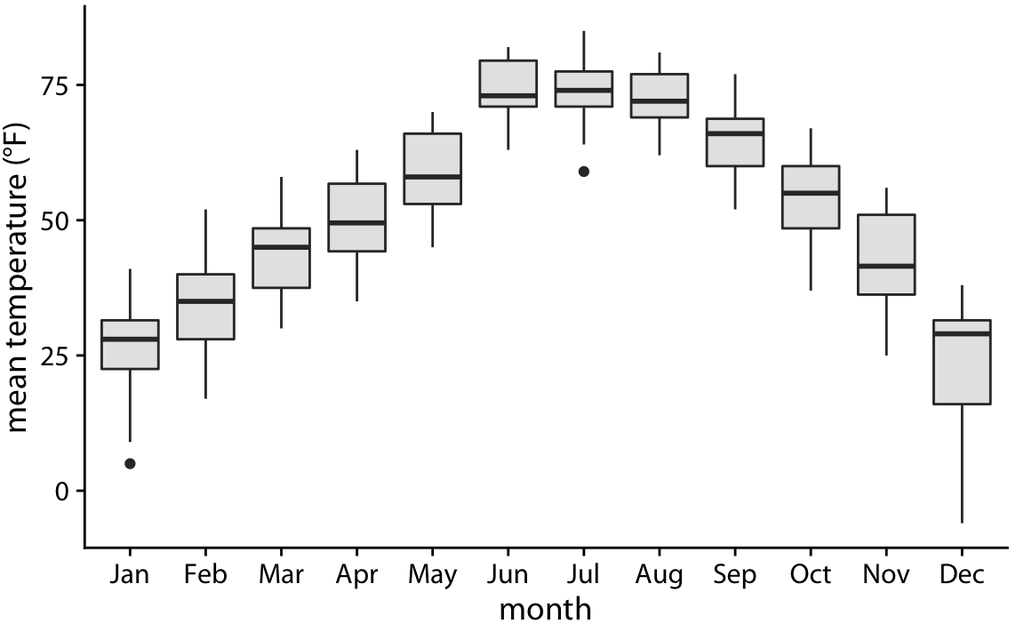

Fuente: Fundamentals of Data Visualization

En este caso, tenemos una **caja** por cada mes del año. Cada caja representa los registros de temperatura de ese mes.

Que podemos observar en el gráfico anterior?:

- Que Junio, Julio y Agosto suelen ser los meses más calurosos de esa ciudad.
- Que diciembre suele ser el mes de mayor amplitud.
- Que diciembre y enero suelen ser los meses más fríos.
- Que la temperatura varía de entre 0 y 75 grados Farenheit a lo largo del año.

El *boxplot* o diagrama de cajas es el método mas simple para mostrar muchas distribuciones al mismo tiempo (y compararlas). Además de poder conocer estadísticas descriptivas y de forma comparada.

Ahora tratemos de hacer un diagrama de cajas. Hoy trabajaremos con datos de la temporada 2021 de la [NBA](https://www.nba.com/players). Una de las nociones más importantes que pueden aprender de este curso, es que la forma de manipular y trabajar con datos de Basquet, de residuos urbanos, o de elecciones ES EXACTAMENTE EL MISMO. Y que el flujo de trabajo para encarar un proyecto de datos, también. Estamos aprendiendo a usar una caja de herramientas para los datos.

Importemos e inspeccionemos los datos a continuación:

```r
# Iniciamos prendiendo los paquetes e importando los datos

library(tidyverse)
library(janitor)
library(googlesheets4) #NUEVA, para instalar: install.packages("googlesheets4")

#Indicamos que no usamos token para levantar datos de gdrive
gs4_deauth()


# URL
jugadores <- read_sheet("https://docs.google.com/spreadsheets/d/1zkDYEbzPEpV323fFuy2A48h8esDHbDqf1nTXWI2lS_Q/edit?usp=sharing",
                        sheet = "nba_21") %>% #sheet indica el nombre de la hoja
  clean_names() %>% #limpiamos nombres de las vars
  print() #printeamos
```

```
## # A tibble: 605 × 29
##    player       team    age    gp     w     l   min   pts   fgm   fga fg_percent
##    <chr>        <chr> <dbl> <dbl> <dbl> <dbl> <dbl> <dbl> <dbl> <dbl>      <dbl>
##  1 Joel Embiid  PHI      28    68    45    23  33.8  30.6   9.8  19.6       49.9
##  2 LeBron James LAL      37    56    25    31  37.2  30.3  11.4  21.8       52.4
##  3 Giannis Ant… MIL      27    67    45    22  32.9  29.9  10.3  18.6       55.3
##  4 Kevin Durant BKN      33    55    36    19  37.2  29.9  10.5  20.3       51.8
##  5 Luka Doncic  DAL      23    65    44    21  35.4  28.4   9.9  21.6       45.7
##  6 Trae Young   ATL      23    76    40    36  34.9  28.4   9.4  20.3       46
##  7 DeMar DeRoz… CHI      32    76    43    33  36.1  27.9  10.2  20.2       50.4
##  8 Kyrie Irving BKN      30    29    14    15  37.6  27.4  10    21.2       46.9
##  9 Ja Morant    MEM      22    57    36    21  33.1  27.4  10.2  20.6       49.3
## 10 Nikola Jokic DEN      27    74    46    28  33.5  27.1  10.3  17.7       58.3
## # … with 595 more rows, and 18 more variables: x3pointmade <dbl>, x3pa <dbl>,
## #   x3p_percent <dbl>, ftm <dbl>, fta <dbl>, ft_percent <dbl>, oreb <dbl>,
## #   dreb <dbl>, reb <dbl>, ast <dbl>, tov <dbl>, stl <dbl>, blk <dbl>,
## #   pf <dbl>, fp <dbl>, dd2 <dbl>, td3 <dbl>, plus_minus <dbl>
```

```r
equipos <- read_sheet("https://docs.google.com/spreadsheets/d/1zkDYEbzPEpV323fFuy2A48h8esDHbDqf1nTXWI2lS_Q/edit?usp=sharing",sheet = "equipos") %>%
  clean_names() %>%
  print()
```

```
## # A tibble: 30 × 7
##    division team                location    arena capacity conference team_short
##    <chr>    <chr>               <chr>       <chr>    <dbl> <chr>      <chr>
##  1 Atlantic Boston Celtics      Boston, Ma… TD G…    19156 Eastern    BOS
##  2 Atlantic Brooklyn Nets       New York C… Barc…    17732 Eastern    BKN
##  3 Atlantic New York Knicks     New York C… Madi…    19812 Eastern    NYK
##  4 Atlantic Philadelphia 76ers  Philadelph… Well…    20478 Eastern    PHI
##  5 Atlantic Toronto Raptors     Toronto, O… Scot…    19800 Eastern    TOR
##  6 Central  Chicago Bulls       Chicago, I… Unit…    20917 Eastern    CHI
##  7 Central  Cleveland Cavaliers Cleveland,… Rock…    19432 Eastern    CLE
##  8 Central  Detroit Pistons     Detroit, M… Litt…    20332 Eastern    DET
##  9 Central  Indiana Pacers      Indianapol… Gain…    17923 Eastern    IND
## 10 Central  Milwaukee Bucks     Milwaukee,… Fise…    17341 Eastern    MIL
## # … with 20 more rows
```

Como ven, hemos importado los datos desde una Google Sheets. Si quieren saber más al respecto, pueden consultar [aquí](https://googlesheets4.tidyverse.org/).

Ahora utilicemos summary para conocer un poco nuestros datos.

```r
summary(jugadores)
```

```
##     player              team                age              gp
##  Length:605         Length:605         Min.   :19.00   Min.   : 1.00
##  Class :character   Class :character   1st Qu.:23.00   1st Qu.:17.00
##  Mode  :character   Mode  :character   Median :25.00   Median :48.00
##                                        Mean   :26.17   Mean   :43.04
##                                        3rd Qu.:29.00   3rd Qu.:66.00
##                                        Max.   :42.00   Max.   :82.00
##        w               l              min             pts
##  Min.   : 0.00   Min.   : 0.00   Min.   : 0.80   Min.   : 0.00
##  1st Qu.: 8.00   1st Qu.: 9.00   1st Qu.:11.10   1st Qu.: 3.50
##  Median :20.00   Median :22.00   Median :18.10   Median : 6.90
##  Mean   :21.69   Mean   :21.35   Mean   :18.91   Mean   : 8.24
##  3rd Qu.:35.00   3rd Qu.:31.00   3rd Qu.:27.30   3rd Qu.:11.10
##  Max.   :64.00   Max.   :59.00   Max.   :43.50   Max.   :30.60
##       fgm              fga           fg_percent      x3pointmade
##  Min.   : 0.000   Min.   : 0.000   Min.   :  0.00   Min.   :0.0000
##  1st Qu.: 1.300   1st Qu.: 3.200   1st Qu.: 39.30   1st Qu.:0.2000
##  Median : 2.600   Median : 5.500   Median : 44.10   Median :0.7000
##  Mean   : 3.037   Mean   : 6.722   Mean   : 43.19   Mean   :0.9155
##  3rd Qu.: 4.100   3rd Qu.: 9.100   3rd Qu.: 49.60   3rd Qu.:1.4000
##  Max.   :11.400   Max.   :21.800   Max.   :100.00   Max.   :4.5000
##       x3pa         x3p_percent          ftm             fta
##  Min.   : 0.000   Min.   :  0.00   Min.   :0.000   Min.   : 0.000
##  1st Qu.: 0.900   1st Qu.: 23.70   1st Qu.:0.400   1st Qu.: 0.600
##  Median : 2.100   Median : 32.70   Median :0.900   Median : 1.200
##  Mean   : 2.686   Mean   : 28.25   Mean   :1.254   Mean   : 1.634
##  3rd Qu.: 4.100   3rd Qu.: 36.90   3rd Qu.:1.600   3rd Qu.: 2.200
##  Max.   :11.700   Max.   :100.00   Max.   :9.600   Max.   :11.800
##    ft_percent          oreb             dreb             reb
##  Min.   :  0.00   Min.   :0.0000   Min.   : 0.000   Min.   : 0.000
##  1st Qu.: 62.50   1st Qu.:0.3000   1st Qu.: 1.300   1st Qu.: 1.800
##  Median : 75.30   Median :0.6000   Median : 2.400   Median : 3.000
##  Mean   : 67.47   Mean   :0.8251   Mean   : 2.622   Mean   : 3.447
##  3rd Qu.: 83.60   3rd Qu.:1.1000   3rd Qu.: 3.500   3rd Qu.: 4.500
##  Max.   :100.00   Max.   :4.6000   Max.   :11.000   Max.   :14.700
##       ast              tov             stl              blk
##  Min.   : 0.000   Min.   :0.000   Min.   :0.0000   Min.   :0.0000
##  1st Qu.: 0.600   1st Qu.:0.500   1st Qu.:0.3000   1st Qu.:0.1000
##  Median : 1.200   Median :0.800   Median :0.5000   Median :0.3000
##  Mean   : 1.868   Mean   :1.016   Mean   :0.6068   Mean   :0.3694
##  3rd Qu.: 2.500   3rd Qu.:1.300   3rd Qu.:0.9000   3rd Qu.:0.5000
##  Max.   :10.800   Max.   :4.500   Max.   :2.3000   Max.   :2.8000
##        pf              fp             dd2              td3
##  Min.   :0.000   Min.   :-0.50   Min.   : 0.000   Min.   : 0.0000
##  1st Qu.:1.000   1st Qu.: 8.20   1st Qu.: 0.000   1st Qu.: 0.0000
##  Median :1.600   Median :15.30   Median : 0.000   Median : 0.0000
##  Mean   :1.601   Mean   :17.08   Mean   : 3.554   Mean   : 0.2149
##  3rd Qu.:2.200   3rd Qu.:23.10   3rd Qu.: 2.000   3rd Qu.: 0.0000
##  Max.   :3.800   Max.   :58.60   Max.   :66.000   Max.   :19.0000
##    plus_minus
##  Min.   :-30.7000
##  1st Qu.: -2.4000
##  Median : -0.5000
##  Mean   : -0.6559
##  3rd Qu.:  1.4000
##  Max.   : 12.0000
```

Muy bien, digamos que nos gustaría saber la distribución de la edad de los jugadores de la NBA. ¿Que hacemos? Un boxplot

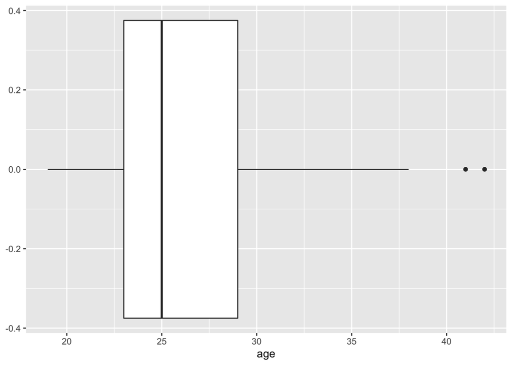

```r
jugadores %>%
  ggplot() +
  geom_boxplot(aes(x = age))
```

¿Que nos dice el gráfico anterior?

Los equipos de la NBA se dividen por conferencias y divisiones.

[figure not shown]

Fuente: Reddit

Digamos que nos interesan saber más cosas al respecto de la edad de los jugadores referidos a su conferencia y a sus divisiones.

Como vimos al principio, nuestra base `jugadores` tiene datos sobre equipo de pertenencia, no sobre equipos. Asi que recurriremos a nuestros amigos de la clase 3 para obtener el dato que necesitamos.

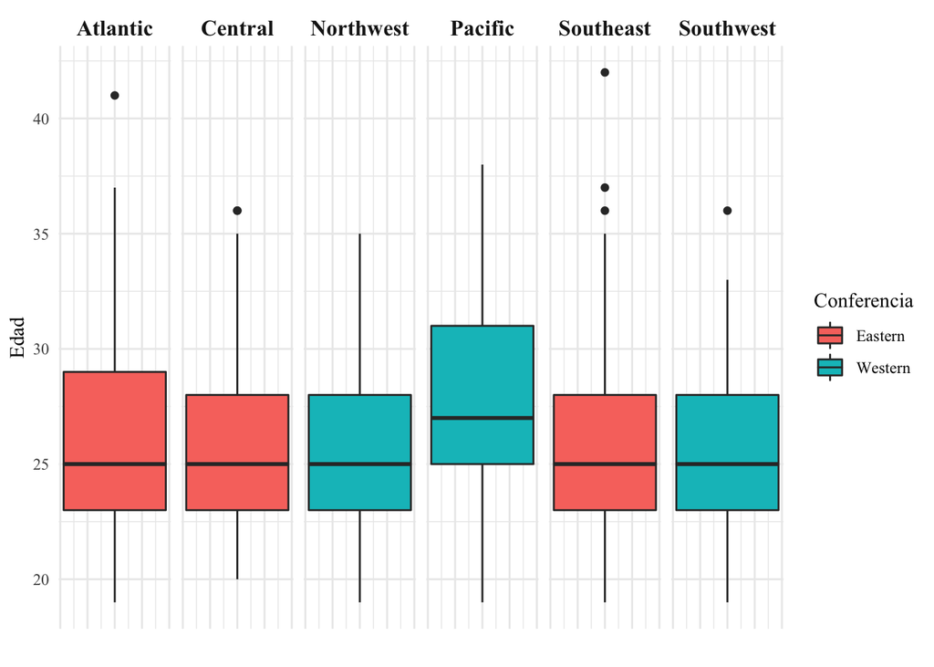

```r
jugadores %>%
  left_join(equipos,by = c("team" = "team_short")) %>%
  rename(team_short = team,
         team_long = team.y) %>%
  ggplot() +
  geom_boxplot(aes(x = age, fill = conference)) +
  facet_grid(~division) +
  coord_flip() +
  labs(y = "",
       x = "Edad",
       fill = "Conferencia") +
  theme_minimal() +
  theme(axis.text.x = element_blank(),
        strip.text = element_text(face = "bold", size = 12),
        text = element_text(family = "Times New Roman"))
```

Como observarán en el código anterior, hemos hecho más cosas que solo plotear lo que deseamos. Hemos **tuneado** un poco nuestro gráfico.

Por ejemplo:

- Con `facet_grid()` hemos dividido un gráfico en un función de una variable (pueden googlear sobre el facet_wrap() y las diferencias al respecto).
- Con `coord_flip()` hemos invertido los ejes del gráfico. Nuestra x ahora es una y.
- Con `labs()` hemos modificado los nombres de nuestros ejes.
- Con `theme_minimal()` le sacamos tinta a nuestro gráfico. Para ver más al respecto pueden buscar sobre el autor Edward Tufte
- Con `theme()` hicimos varias cosas. En primer lugar le quitamos el texto al eje x, le pusimos negrita al texto del título del facetado y le aumentamos el tamaño. También pusimos todo en Times New Roman, es decir, cambiamos la fuente original.

Algunas de estas cosas las pueden consultar en el libro de [Claus Wilke](https://clauswilke.com/dataviz/), en el blog de [Ggplot2](https://ggplot2.tidyverse.org/articles/faq-faceting.html), en los blogs de grosos como [Toni VB](https://bitsandbricks.github.io/) o en la [galería de plots de R](https://r-graph-gallery.com/ggplot2-package.html)

Existen **variantes** del clásico boxplot. Agregando puntos, barras, cambiando los contornos, etc. Pueden averiguar [más aquí](https://r-graph-gallery.com/boxplot.html).

# Representar proporciones

Sigamos analizando nuestros datos de la NBA, que tal si nos interesa saber que porcentaje de los equipos de la NBA pertenecen a la división del **Atlántico**.

Tal pregunta, es una pregunta con respecto a una proporción del todo. Queremos saber que parte representa x de y.

Antes de responderla, pensemos como nos gustaría responderla visualmente.Tenemos muy arraigado pensar en gráficos de torta, porque se asemejan a las proporciones. Pero pensemos en los siguientes ejemplos:

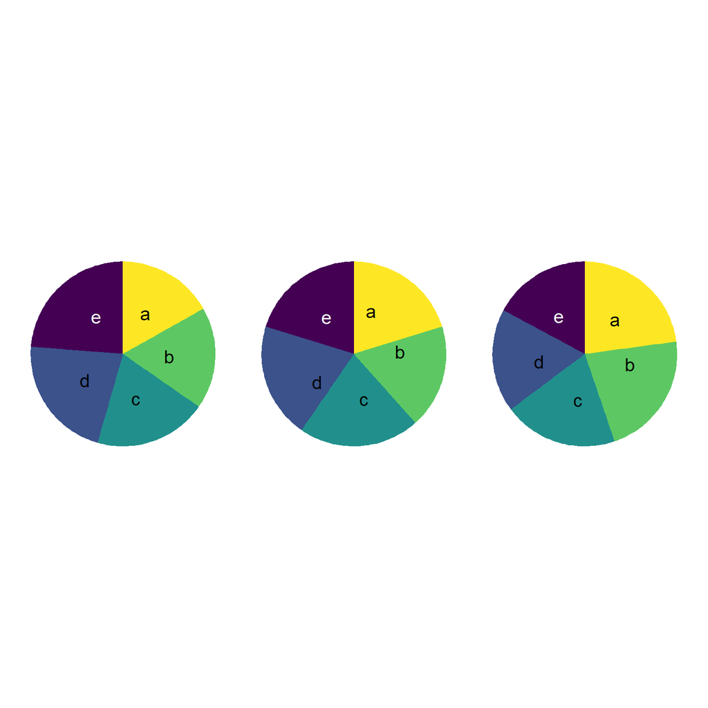

Fuente: Data to Viz

¿Notan alguna diferencia con respecto a los 3?

La relación de cada porción de torta con el total no es visualmente obvia. En general, los gráficos de torta trabajan “bien” cuando el objetivo es hacer énfasis en fracciones simples. Por ejemplo (números inventados):

- “La mitad del tráfico aéreo corresponde a X aerolínea”.
- “Un tercio de los goles de penal son errados”.
- “Un cuarto de los casos de dengue derivan en hospitalizaciones”,

También trabajan bien para representar proporciones en bases pequeñas.

Pero…

**El ojo humano no está entrenador para diferenciar ángulos de la misma forma que podemos diferenciar barras**

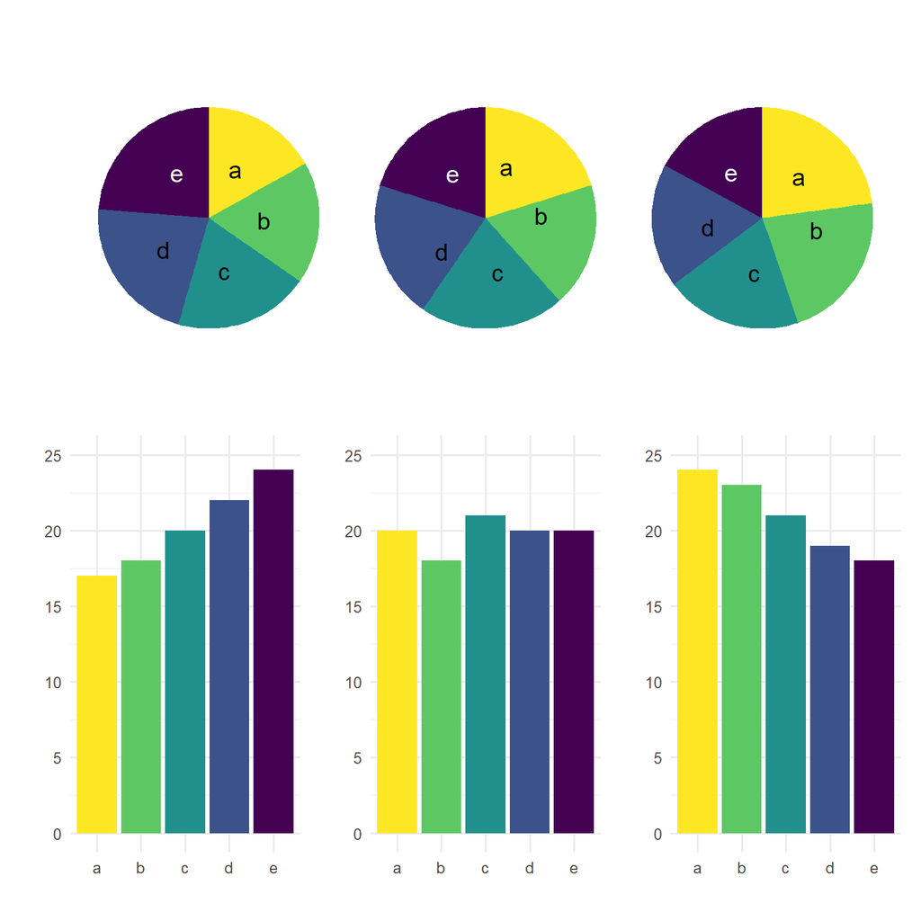

Fuente: Data to Viz

Dicho esto, nuestro querido amigo gráfico de torta, suele tener problemas cuando hablamos de representaciones de proporciones. No siempre es útil. Existen gráficos alternativos como los diagramas de árbol o los waffles que nos permitirían resolver algunos de los dolores de cabeza que nos dan los pie charts.

No obstante, ningún gráfico es mejor que otro *per se*. Si les interesa la discusión alrededor de los gráficos de torta, pueden leer una postura [por aquí](https://clauswilke.com/dataviz/visualizing-proportions.html#a-case-for-pie-charts) y por [aquí](https://www.data-to-viz.com/caveat/pie.html#).

## geom_waffle()

El waffle chart tiene dos funciones principales.

- Mostrar el progreso de una variable con respecto a un porcentaje de completitud.
- Representar partes de un todo (proporciones)

Veamos ejemplos

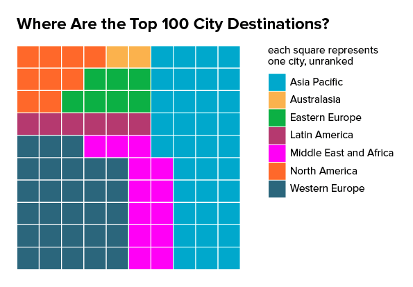

Fuente: datavizproject.com

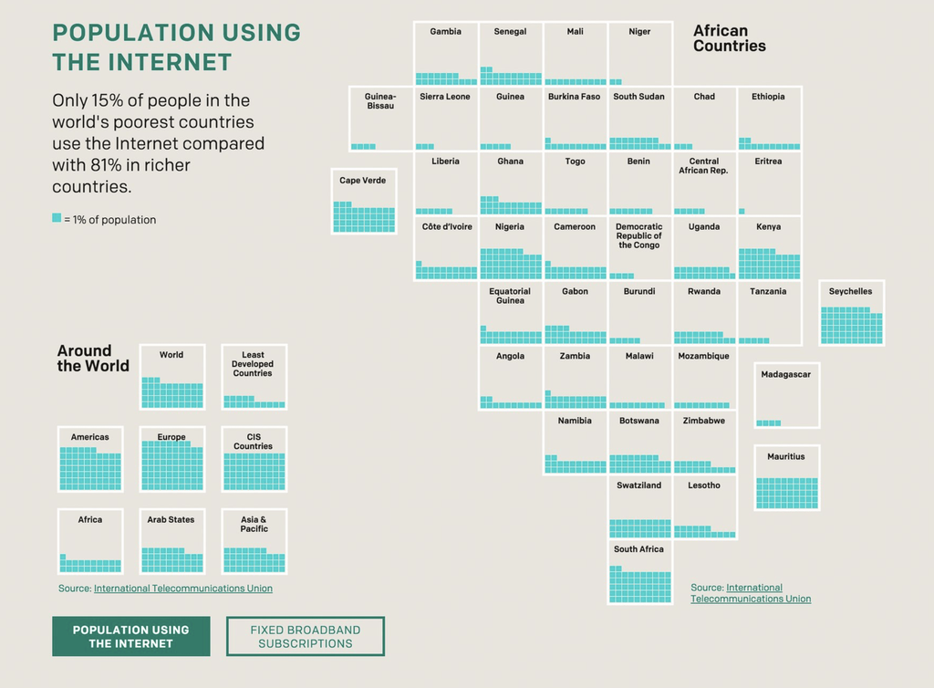

Fuente: datavizproject.com

[figure not shown]

Fuente: datavizproject.com

**Veamos como hacer uno para nuestra pregunta de la NBA**

**¿Qué porcentaje de los equipos de la NBA pertenecen a la división Atlático?**

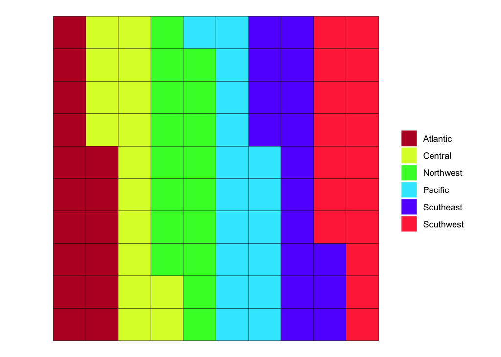

```r
#Instalamos la librería de waffle

#install.packages("waffle")
library(waffle)

divisiones <- equipos %>%
  group_by(division) %>%
  count()

divisiones_plot <- ggplot(data = divisiones, aes(fill = division, values = n)) +
  geom_waffle(n_rows = 10, make_proportional = T) +
  scale_fill_manual(name = NULL,
                    values = c("#BA182A", "#DAFF33", "#39FF33","#33E9FF", "#6433FF","#FF3346"),
                    labels = c("Atlantic", "Central", "Northwest","Pacific","Southeast","Southwest")) +
  coord_equal() +
  theme_void()

divisiones_plot
```

Ahora juguemos un poco con la library [ggthemes](https://yutannihilation.github.io/allYourFigureAreBelongToUs/ggthemes/).

Pueden chusmear este post [después](https://rud.is/b/2019/07/12/quick-hit-waffle-1-0-font-awesome-5-pictograms-and-more/)

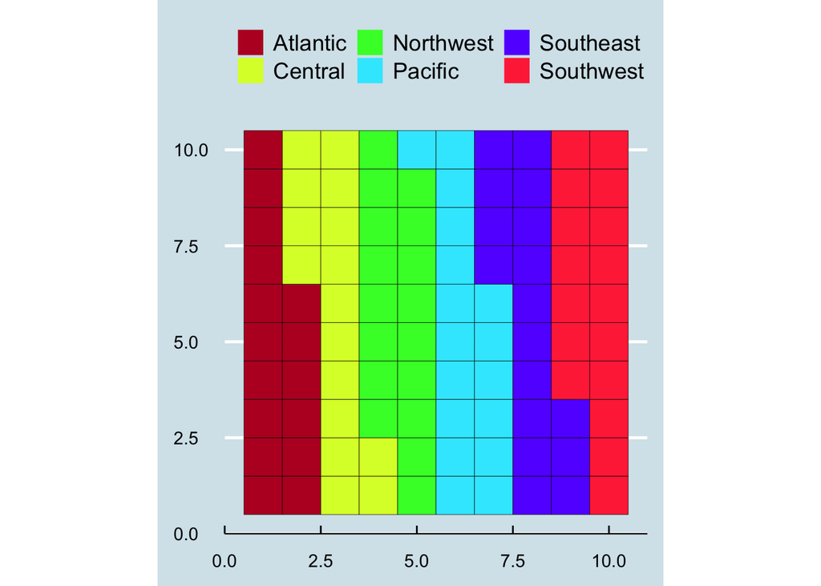

```r
library(ggthemes)

divisiones_plot +
  ggthemes::theme_economist()
```

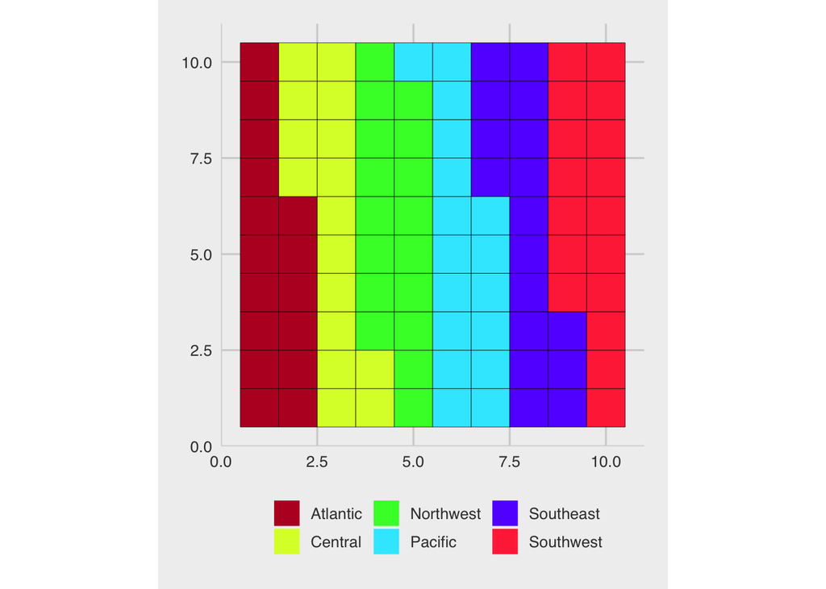

```r
divisiones_plot +
  ggthemes::theme_fivethirtyeight()
```

## geom_treemap()

También se podría representar como un diagrama de árbol, que además de las divisiones, nos incorpore las conferencias como un subgrupo

Veamos como hacer uno:

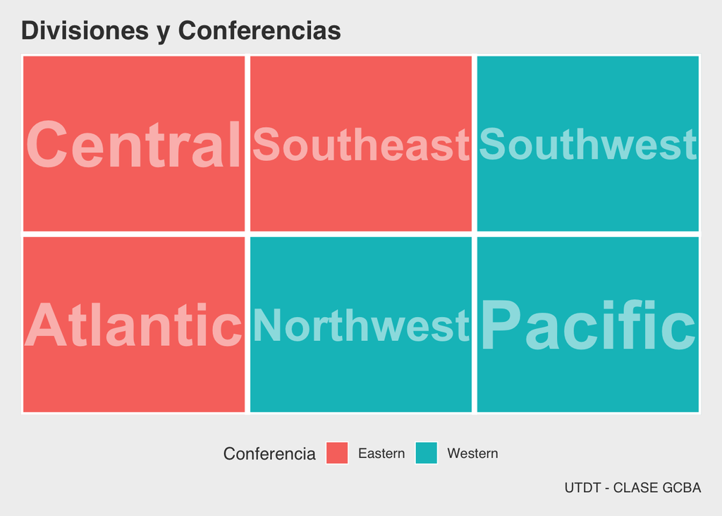

```r
# install.packages("treemapify")
library(treemapify)

divisiones_conferencia <- equipos %>%
  group_by(conference, division) %>%
  count()

ggplot(divisiones_conferencia, aes(area = n, fill = conference,
               label = conference, subgroup = division)) +
  geom_treemap() +
  geom_treemap_subgroup_border(colour = "white", size = 5) +
  geom_treemap_subgroup_text(place = "centre", grow = TRUE,
                             alpha = 0.5, colour = "white",
                             fontface = "bold") +
    labs(title = "Divisiones y Conferencias",
         caption = "UTDT - CLASE GCBA",
       fill = "Conferencia") +
  theme_fivethirtyeight()
```

**La percepción humana es mejor al juzgar distancias que al juzgar áreas. Por tal motivo, el treemap también tiene problemas.**

# Ejercicios

1. Abrir RStudio y crear un nuevo proyecto de R.
2. Descargar e importar la base de datos del [mapa del delito 2021](https://data.buenosaires.gob.ar/dataset/delitos) de BA Data, si decide importarla descargando, guárdela en la carpeta “data”dentro del proyecto.
3. Realice una transformación y una breve descripción de al menos 5 variables de la base de datos.
4. Realice 2 visualizaciones de datos (en lo posible, que un gráfico no haya sido visto en clase).
5. Comente los hallazgos e impresiones de los gráficos, también justifique su elección (por que ese gráfico y no otro?)
6. Al realizar los gráficos, no olvide añadir titulo, subtítulo, fuente, cambiar colores, etc.
7. Una vez finalizado el ejercicio, generar el reporte HTML con “Knit”.